# HR_script

crodrigu

February 05, 2017

# The Business Questions

The data set being used contains information regarding the employment statsitics and habits of a company from the HR department. The following are the criteria illustrated in the dataset:

1. Satisfaction level - a number between 0 and 1 - level of satisfaction in current function
2. Evaluation - number between 0 and 1 -
3. Number of projects - number of projects
4. Average monthly hours
5. Time spent company - number of years worked for the company
6. Work accident - 0 if you’ve had a work accident, 1 if you have
7. Left - 1 if you’ve left the company, 0 means you haven’t
8. Promotion - 1 if you’ve had a promotion in the last 5 years, and 0 and if you haven’t
9. Department - qualitative (string)
10. Salary - text - “high”, “medium” “low”

Based on the given criteria the business questions that were investigated for the purpose of report:

1. Why are employees leaving?
2. What are the three most important factors for people leaving as compared to staying?
1. Are we overworking the top performers?
2. Is money most important? Is satsifaction most important?
3. Department vs. Global Trends - do we have bad managers?
3. How can we keep employees using the information that we derive from the data? Can we identify people who are leaving
4. Can we identify loyal employees?
5. Turnover per department?

## Part 1

Number of current employees: [1] 11428

Number of employees who have left: [1] 3571

## Part 2: Comparison between current employees and those who left:

*Employee Satisfaction*

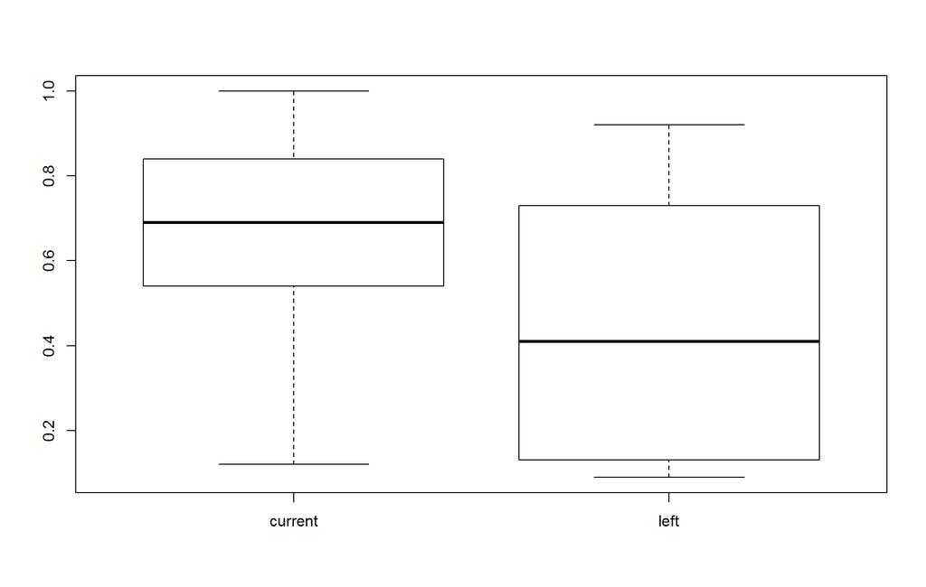

*Employee Evaluation*

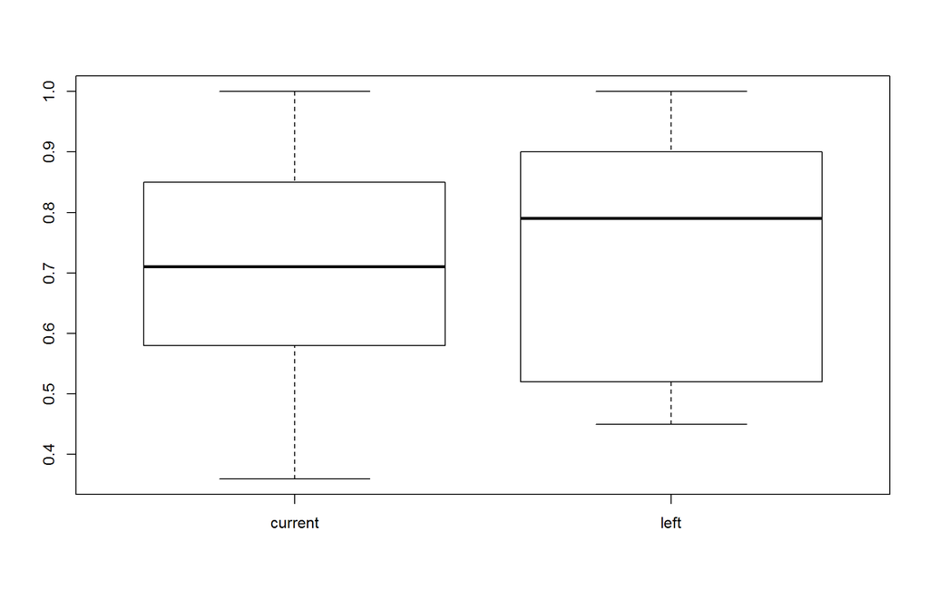

*Employee Working Hours*

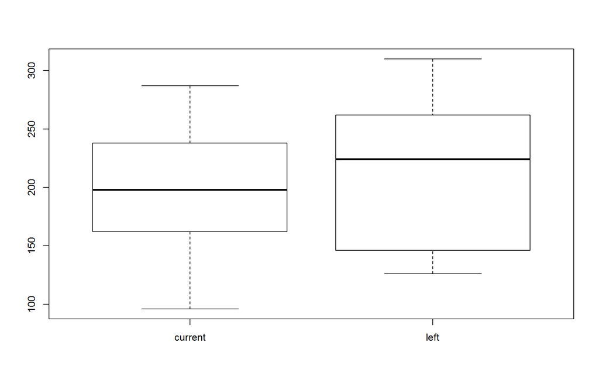

*General Term of Employees*

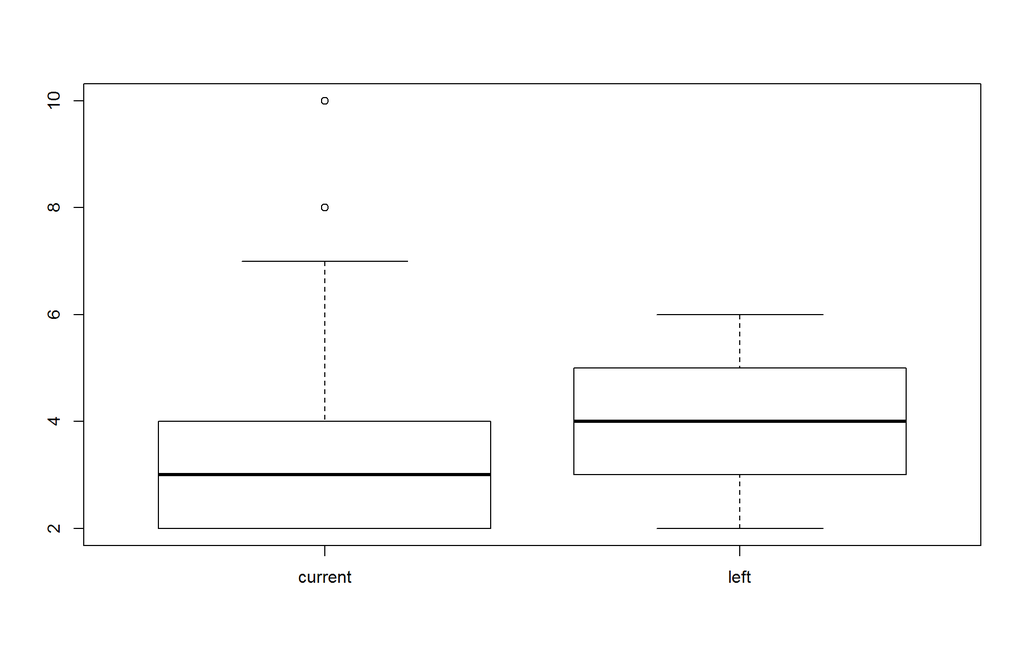

The current employees have spent on average fewer years than the employees who left. This could indicate that the number of years that the employees who left worked is the general term of an employee at the company. This can be the natural turnover rate.

*Number of Employee Projects*

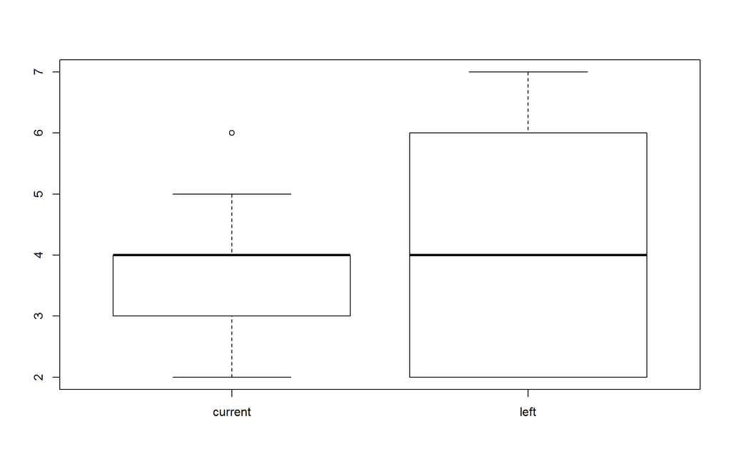

The average number of projects that employees who leave is higher than that of those who are still employed at the company.

# Department specific analysis

In order to analyse the data per department, we create a table per department.

Then, we calculate the mean parameters of each department.

|  | satisfaction level | last evaluation | number of projects | average monthly hours | time spent in the company | work accident | left company | promotion during last 5 years | salary category |
| --- | --- | --- | --- | --- | --- | --- | --- | --- | --- |
| accounting | 0.58 | 0.72 | 3.83 | 201.16 | 3.52 | 0.13 | 0.27 | 0.02 | 1.63 |
| HR | 0.60 | 0.71 | 3.65 | 198.68 | 3.36 | 0.12 | 0.29 | 0.02 | 1.61 |
| IT | 0.62 | 0.72 | 3.82 | 202.22 | 3.47 | 0.13 | 0.22 | 0.00 | 1.57 |
| management | 0.62 | 0.72 | 3.86 | 201.25 | 4.30 | 0.16 | 0.14 | 0.11 | 2.07 |
| marketing | 0.62 | 0.72 | 3.69 | 199.39 | 3.57 | 0.16 | 0.24 | 0.05 | 1.62 |
| product management | 0.62 | 0.71 | 3.81 | 199.97 | 3.48 | 0.15 | 0.22 | 0.00 | 1.58 |
| research and development | 0.62 | 0.71 | 3.85 | 200.80 | 3.37 | 0.17 | 0.15 | 0.03 | 1.60 |
| sales | 0.61 | 0.71 | 3.78 | 200.91 | 3.53 | 0.14 | 0.24 | 0.02 | 1.56 |
| support | 0.62 | 0.72 | 3.80 | 200.76 | 3.39 | 0.15 | 0.25 | 0.01 | 1.55 |
| technical | 0.61 | 0.72 | 3.88 | 202.50 | 3.41 | 0.14 | 0.26 | 0.01 | 1.57 |

We calculate the standard deviation of each parameter.

|  | satisfaction level | last evaluation | number of projects | average monthly hours | time spent in the company | work accident | left company | promotion during last 5 years | salary category |
| --- | --- | --- | --- | --- | --- | --- | --- | --- | --- |
| accounting | 0.26 | 0.17 | 1.26 | 51.11 | 1.40 | 0.33 | 0.44 | 0.13 | 1.63 |
| HR | 0.25 | 0.17 | 1.23 | 50.37 | 1.17 | 0.33 | 0.45 | 0.14 | 1.61 |
| IT | 0.25 | 0.16 | 1.22 | 50.69 | 1.41 | 0.34 | 0.42 | 0.05 | 1.57 |
| management | 0.23 | 0.16 | 1.18 | 47.38 | 2.43 | 0.37 | 0.35 | 0.31 | 2.07 |
| marketing | 0.24 | 0.17 | 1.21 | 49.36 | 1.54 | 0.37 | 0.43 | 0.22 | 1.62 |
| product management | 0.24 | 0.18 | 1.24 | 50.11 | 1.43 | 0.35 | 0.41 | 0.00 | 1.58 |
| research and development | 0.25 | 0.17 | 1.16 | 49.25 | 1.21 | 0.38 | 0.36 | 0.18 | 1.60 |
| sales | 0.25 | 0.17 | 1.24 | 49.56 | 1.51 | 0.35 | 0.43 | 0.15 | 1.56 |
| support | 0.25 | 0.17 | 1.21 | 50.02 | 1.34 | 0.36 | 0.43 | 0.09 | 1.55 |
| technical | 0.25 | 0.17 | 1.26 | 50.60 | 1.26 | 0.35 | 0.44 | 0.10 | 1.57 |

We calculate the minimum value of each parameter.

|  | satisfaction level | last evaluation | number of projects | average monthly hours | time spent in the company | work accident | left company | promotion during last 5 years | salary category |
| --- | --- | --- | --- | --- | --- | --- | --- | --- | --- |
| accounting | 0.09 | 0.36 | 2 | 97 | 2 | 0 | 0 | 0 | 1.63 |
| HR | 0.09 | 0.37 | 2 | 98 | 2 | 0 | 0 | 0 | 1.61 |
| IT | 0.09 | 0.37 | 2 | 96 | 2 | 0 | 0 | 0 | 1.57 |
| management | 0.09 | 0.37 | 2 | 97 | 2 | 0 | 0 | 0 | 2.07 |
| marketing | 0.09 | 0.36 | 2 | 96 | 2 | 0 | 0 | 0 | 1.62 |
| product management | 0.09 | 0.36 | 2 | 98 | 2 | 0 | 0 | 0 | 1.58 |
| research and development | 0.09 | 0.36 | 2 | 98 | 2 | 0 | 0 | 0 | 1.60 |
| sales | 0.09 | 0.36 | 2 | 96 | 2 | 0 | 0 | 0 | 1.56 |
| support | 0.09 | 0.36 | 2 | 96 | 2 | 0 | 0 | 0 | 1.55 |
| technical | 0.09 | 0.36 | 2 | 97 | 2 | 0 | 0 | 0 | 1.57 |

We calculate the maxiimum value of each parameter.

|  | satisfaction level | last evaluation | number of projects | average monthly hours | time spent in the company | work accident | left company | promotion during last 5 years | salary category |
| --- | --- | --- | --- | --- | --- | --- | --- | --- | --- |
| accounting | 1 | 1 | 7 | 310 | 10 | 1 | 1 | 1 | 1.63 |
| HR | 1 | 1 | 7 | 310 | 8 | 1 | 1 | 1 | 1.61 |
| IT | 1 | 1 | 7 | 308 | 10 | 1 | 1 | 1 | 1.57 |
| management | 1 | 1 | 7 | 307 | 10 | 1 | 1 | 1 | 2.07 |
| marketing | 1 | 1 | 7 | 310 | 10 | 1 | 1 | 1 | 1.62 |
| product management | 1 | 1 | 7 | 310 | 10 | 1 | 1 | 0 | 1.58 |
| research and development | 1 | 1 | 7 | 308 | 8 | 1 | 1 | 1 | 1.60 |
| sales | 1 | 1 | 7 | 310 | 10 | 1 | 1 | 1 | 1.56 |
| support | 1 | 1 | 7 | 310 | 10 | 1 | 1 | 1 | 1.55 |
| technical | 1 | 1 | 7 | 310 | 10 | 1 | 1 | 1 | 1.57 |

# Factor Analysis

```r
# Please ENTER then original raw attributes to use.  Please use numbers, not
# column names, e.g. c(1:5, 7, 8) uses columns 1,2,3,4,5,7,8
factor_attributes_used = c(1:10)

# Please ENTER the selection criterions for the factors to use.  Choices:
# 'eigenvalue', 'variance', 'manual'
factor_selectionciterion = "manual"

# Please ENTER the desired minumum variance explained (Only used in case
# 'variance' is the factor selection criterion used).
minimum_variance_explained = 65  # between 1 and 100

# Please ENTER the number of factors to use (Only used in case 'manual' is
# the factor selection criterion used).
manual_numb_factors_used = 3

# Please ENTER the rotation eventually used (e.g. 'none', 'varimax',
# 'quatimax', 'promax', 'oblimin', 'simplimax', and 'cluster' - see
# help(principal)). Default is 'varimax'
rotation_used = "varimax"
```

First, we apply the factors and scale the data

# Visual exploration of the data

|  | Obs.01 | Obs.02 | Obs.03 | Obs.04 | Obs.05 | Obs.06 | Obs.07 | Obs.08 | Obs.09 | Obs.10 |
| --- | --- | --- | --- | --- | --- | --- | --- | --- | --- | --- |
| satisfaction_level | -0.94 | 0.75 | -2.02 | 0.43 | -0.98 | -0.82 | -2.06 | 1.24 | 1.11 | -0.78 |
| last_evaluation | -1.09 | 0.84 | 0.96 | 0.90 | -1.15 | -1.26 | 0.31 | 0.78 | 1.66 | -1.09 |
| number_project | -1.46 | 0.97 | 2.59 | 0.97 | -1.46 | -1.46 | 1.78 | 0.97 | 0.97 | -1.46 |
| average_montly_hours | -0.88 | 1.22 | 1.42 | 0.44 | -0.84 | -0.96 | 0.92 | 1.16 | 0.46 | -1.18 |
| time_spend_company | -0.34 | 1.71 | 0.34 | 1.03 | -0.34 | -0.34 | 0.34 | 1.03 | 1.03 | -0.34 |
| Work_accident | -0.41 | -0.41 | -0.41 | -0.41 | -0.41 | -0.41 | -0.41 | -0.41 | -0.41 | -0.41 |
| left | 1.79 | 1.79 | 1.79 | 1.79 | 1.79 | 1.79 | 1.79 | 1.79 | 1.79 | 1.79 |
| promotion_last_5years | -0.15 | -0.15 | -0.15 | -0.15 | -0.15 | -0.15 | -0.15 | -0.15 | -0.15 | -0.15 |
| Department | 0.39 | 0.39 | 0.39 | 0.39 | 0.39 | 0.39 | 0.39 | 0.39 | 0.39 | 0.39 |
| salary | -0.55 | 1.04 | 1.04 | -0.55 | -0.55 | -0.55 | -0.55 | -0.55 | -0.55 | -0.55 |

The data we use here have the following descriptive statistics:

|  | min | 25 percent | median | mean | 75 percent | max | std |
| --- | --- | --- | --- | --- | --- | --- | --- |
| satisfaction_level | -2.10 | -0.70 | 0.11 | 0 | 0.83 | 1.56 | 1 |
| last_evaluation | -2.08 | -0.91 | 0.02 | 0 | 0.90 | 1.66 | 1 |
| number_project | -1.46 | -0.65 | 0.16 | 0 | 0.97 | 2.59 | 1 |
| average_montly_hours | -2.10 | -0.90 | -0.02 | 0 | 0.88 | 2.18 | 1 |
| time_spend_company | -1.03 | -0.34 | -0.34 | 0 | 0.34 | 4.45 | 1 |
| Work_accident | -0.41 | -0.41 | -0.41 | 0 | -0.41 | 2.43 | 1 |
| left | -0.56 | -0.56 | -0.56 | 0 | -0.56 | 1.79 | 1 |
| promotion_last_5years | -0.15 | -0.15 | -0.15 | 0 | -0.15 | 6.78 | 1 |
| Department | -2.16 | -0.70 | 0.39 | 0 | 0.75 | 1.12 | 1 |
| salary | -2.15 | -0.55 | -0.55 | 0 | 1.04 | 1.04 | 1 |

## Check Correlations

|  | satisfaction_level | last_evaluation | number_project | average_montly_hours | time_spend_company | Work_accident | left | promotion_last_5years | Department | salary |
| --- | --- | --- | --- | --- | --- | --- | --- | --- | --- | --- |
| satisfaction_level | 1.00 | 0.11 | -0.14 | -0.02 | -0.10 | 0.06 | -0.39 | 0.03 | 0.01 | 0.01 |
| last_evaluation | 0.11 | 1.00 | 0.35 | 0.34 | 0.13 | -0.01 | 0.01 | -0.01 | 0.01 | 0.01 |
| number_project | -0.14 | 0.35 | 1.00 | 0.42 | 0.20 | 0.00 | 0.02 | -0.01 | 0.02 | 0.01 |
| average_montly_hours | -0.02 | 0.34 | 0.42 | 1.00 | 0.13 | -0.01 | 0.07 | 0.00 | 0.01 | 0.01 |
| time_spend_company | -0.10 | 0.13 | 0.20 | 0.13 | 1.00 | 0.00 | 0.14 | 0.07 | -0.03 | 0.00 |
| Work_accident | 0.06 | -0.01 | 0.00 | -0.01 | 0.00 | 1.00 | -0.15 | 0.04 | 0.01 | 0.00 |
| left | -0.39 | 0.01 | 0.02 | 0.07 | 0.14 | -0.15 | 1.00 | -0.06 | 0.01 | 0.00 |
| promotion_last_5years | 0.03 | -0.01 | -0.01 | 0.00 | 0.07 | 0.04 | -0.06 | 1.00 | -0.04 | 0.00 |
| Department | 0.01 | 0.01 | 0.02 | 0.01 | -0.03 | 0.01 | 0.01 | -0.04 | 1.00 | 0.02 |
| salary | 0.01 | 0.01 | 0.01 | 0.01 | 0.00 | 0.00 | 0.00 | 0.00 | 0.02 | 1.00 |

## Choose number of factors - Principal Factor analysis

Let’s look at the **variance explained** as well as the **eigenvalues** :

|  | Eigenvalue | Pct of explained variance | Cumulative pct of explained variance |
| --- | --- | --- | --- |
| Component 1 | 1.86 | 18.61 | 18.61 |
| Component 2 | 1.46 | 14.65 | 33.26 |
| Component 3 | 1.09 | 10.87 | 44.12 |
| Component 4 | 1.00 | 10.03 | 54.15 |
| Component 5 | 0.99 | 9.91 | 64.06 |
| Component 6 | 0.94 | 9.38 | 73.44 |
| Component 7 | 0.84 | 8.44 | 81.88 |
| Component 8 | 0.71 | 7.09 | 88.97 |
| Component 9 | 0.63 | 6.26 | 95.23 |
| Component 10 | 0.48 | 4.77 | 100.00 |

[interactive chart not shown]

# Interpret the factors

Let’s now see how the “top factors” look like.

# Rotation applied on factors

|  | Comp.1 | Comp.2 | Comp.3 |
| --- | --- | --- | --- |
| number_project | 0.77 | -0.11 | 0.01 |
| average_montly_hours | 0.75 | -0.03 | -0.06 |
| last_evaluation | 0.73 | 0.15 | -0.09 |
| time_spend_company | 0.36 | -0.27 | 0.46 |
| left | 0.04 | -0.80 | 0.00 |
| Department | 0.04 | 0.00 | -0.51 |
| salary | 0.04 | 0.02 | -0.17 |
| Work_accident | 0.01 | 0.36 | 0.28 |
| satisfaction_level | 0.00 | 0.78 | -0.13 |
| promotion_last_5years | 0.00 | 0.16 | 0.70 |

To better visualize and interpret the factors we often “suppress” loadings with small values, e.g. with absolute values smaller than 0.5. In this case our factors look as follows after suppressing the small numbers:

|  | Comp.1 | Comp.2 | Comp.3 |
| --- | --- | --- | --- |
| number_project | 0.77 |  |  |
| average_montly_hours | 0.75 |  |  |
| last_evaluation | 0.73 |  |  |
| time_spend_company |  |  |  |
| left |  | -0.80 |  |
| Department |  |  | -0.51 |
| salary |  |  |  |
| Work_accident |  |  |  |
| satisfaction_level |  | 0.78 |  |
| promotion_last_5years |  |  | 0.70 |

# Save factor scores

We can now either replace all initial variables used in this part with the factors scores or just select one of the initial variables for each of the selected factors in order to represent that factor. Here is how the factor scores are for the first few respondents:

|  | Obs.01 | Obs.02 | Obs.03 | Obs.04 | Obs.05 | Obs.06 | Obs.07 | Obs.08 | Obs.09 | Obs.10 |
| --- | --- | --- | --- | --- | --- | --- | --- | --- | --- | --- |
| DV (Factor) 1 | -1.56 | 1.60 | 2.06 | 1.13 | -1.57 | -1.66 | 1.21 | 1.41 | 1.47 | -1.68 |
| DV (Factor) 2 | -1.61 | -0.85 | -2.12 | -0.94 | -1.63 | -1.57 | -2.22 | -0.53 | -0.49 | -1.53 |
| DV (Factor) 3 | -0.18 | -0.13 | -0.42 | -0.07 | -0.18 | -0.17 | -0.06 | -0.19 | -0.21 | -0.18 |

## Answering the Business Questions:

*1. Why are employees leaving?*

*2. What are the three most important factors for people leaving as compared to staying?*

*a) Are we overworking the top performers?*

*b) Is money most important? Is satisfaction most important?*

The data shows that satisfaction may be an important factor as those who left had a lower level of satisfaction with their job than those who stayed. The raw data captured only split the salary into high, medium and low categories. Withouot more speicifc data it is difficult to draw a conclusion if salary plays a significant part in employe eretention

*c) Department vs. Global Trends - do we have bad managers?*

*3. How can we keep employees using the information that we derive from the data? Can we identify people who are leaving*

*4. Can we identify loyal employees?*

According to the statistics loyal employees are those that would stay for longer despite working long hours, or have a recent lower level of satisfaction.

*5. Turnover per department?*

The turnover per department is as follows

|  | df |
| --- | --- |
| accounting | 0.27 |
| HR | 0.29 |
| IT | 0.22 |
| management | 0.14 |
| marketing | 0.24 |
| product management | 0.22 |
| research and development | 0.15 |
| sales | 0.24 |
| support | 0.25 |
| technical | 0.26 |